1.Use the rbinom() function with probability 0.5 to simulate a string of 100 coin flips.

```r
(coin.flips <- rbinom(100,1,0.5))
```

```
##   [1] 1 1 1 1 1 0 0 1 0 0 0 1 0 1 1 1 0 1 1 1 0 1 1 0 0 1 0 0 1 0 0 0 1 0 0
##  [36] 1 1 0 1 1 0 1 1 0 0 0 1 1 0 1 0 1 0 1 1 0 1 1 0 1 1 0 0 1 0 0 0 1 1 0
##  [71] 1 0 0 1 0 1 1 1 1 0 0 0 0 1 1 1 1 0 0 1 0 0 0 0 1 1 1 0 0 1
```

2.Write code that will test the sequence you just generated to determine whether there is a string of at least seven in a row of either heads or tails. (You can choose whether to consider 0 heads and 1 tails or vice versa.)

My code is designed to end the loop as soon as it finds a 7 consecutive sequence of 0s or 1s in the data. I’m defining Heads as 1s and Tails as 0s. I tested the code extensively and I believe it works correctly. It sets ‘SevenInARow’ to 1 if it succeeds, otherwise it remains at 0.

```r
i <- 1
SevenInARow <- 0
sum.heads <- 0
sum.tails <- 0
while ((SevenInARow == FALSE) && i <= (length(coin.flips) - 6))
{
  sum.heads <- sum(coin.flips[i:(i+6)] == c(1,1,1,1,1,1,1))
  sum.tails <- sum(coin.flips[i:(i+6)] == c(0,0,0,0,0,0,0))
  if ((sum.heads == 7) || (sum.tails == 7))
  {
    SevenInARow <- 1
  }
  i <- i + 1
}
(SevenInARow)
```

```
## [1] 0
```

3.Enclose the code for steps 1 and 2 in a loop so that you can run it a bunch of times. Use this loop to determine the proportion of 100-toss sequences that actually have at least seven in a row of the same thing. This is your estimate of the probability.

4.Run the loop with 10 such sequences. Then run it with 100, and 1000. (If you’re really brave, run it more times still…)

Ok, so **‘Seven.Tests.Num’** sets the number of tests to run and the vector **‘Seven.Tests’** contains **0** or **1** depending on if the test for that set of 100 flips had seven consecutive heads or tails. Then, we can simply look at the **Sum(Seven.Tests) / Length(Seven.Tests)** to estimate the probability.

```r
Seven.Tests.Num = 100
Seven.Tests <- c(1:Seven.Tests.Num)*0

for (j in 1:Seven.Tests.Num)
{
  coin.flips <- rbinom(100,1,0.5)
  i <- 1
  SevenInARow <- 0
  sum.heads <- 0
  sum.tails <- 0
  while ((SevenInARow == FALSE) && i <= (length(coin.flips) - 6))
  {
    sum.heads <- sum(coin.flips[i:(i+6)] == c(1,1,1,1,1,1,1))
    sum.tails <- sum(coin.flips[i:(i+6)] == c(0,0,0,0,0,0,0))
    if ((sum.heads == 7) || (sum.tails == 7))
    {
      SevenInARow <- 1
    }
    i <- i + 1
  }
Seven.Tests[j] = SevenInARow
}
(Seven.Tests)
```

```
##   [1] 0 1 0 1 1 1 1 1 0 0 0 1 0 1 1 1 0 0 0 1 1 1 1 1 1 1 0 0 0 1 0 0 0 0 0
##  [36] 0 0 0 1 1 1 0 1 1 1 1 0 1 0 0 1 1 1 1 0 0 0 1 1 0 0 0 0 0 1 1 1 1 0 1
##  [71] 1 0 0 1 1 1 1 0 1 0 0 1 1 1 1 1 0 1 0 0 1 0 1 0 1 0 0 1 1 1
```

```r
(sum(Seven.Tests)/length(Seven.Tests))
```

```
## [1] 0.55
```

Comment both on how well your estimate seems to converge to a single answer and also how R performs at these loops. Do you notice a significant slowdown at 1000 sequences? What about 10,000? Where does your machine start really to grind to a halt?

My maching took about 53 seconds to do 100,000 loops of 100 Flips. This is my work computer and it’s relatively new which is why this is pretty fast

I figure I’d put 400 trails of 1,000 tests to see if we’re converging onto a number - basically, I just threw *another loop* around the above one and put the resutls into another vector :-)

Then to make things a little nicer to see, I put a the results into a simple data.frame and plotted them with a histogrm. Looks to me like we’re in the 0.54 to 0.55 range as to the probability:

```r
require(ggplot2)
Numbr.Tests <- 400
tests.numerators <- c(1:Numbr.Tests)*0

for (k in 1:Numbr.Tests)
{
  Seven.Tests.Num <- 1000
  Seven.Tests <- c(1:Seven.Tests.Num)*0

  for (j in 1:Seven.Tests.Num)
  {
    coin.flips <- rbinom(100,1,0.5)
    i <- 1
    SevenInARow <- 0
    sum.heads <- 0
    sum.tails <- 0
    while ((SevenInARow == FALSE) && i <= (length(coin.flips) - 6))
    {
      sum.heads <- sum(coin.flips[i:(i+6)] == c(1,1,1,1,1,1,1))
      sum.tails <- sum(coin.flips[i:(i+6)] == c(0,0,0,0,0,0,0))
      if ((sum.heads == 7) || (sum.tails == 7))
      {
        SevenInARow <- 1
      }
      i <- i + 1
    }
    Seven.Tests[j] = SevenInARow
  }
  tests.numerators[k] <- sum(Seven.Tests)
}

TheResults <- data.frame(tests.numerators,Seven.Tests.Num, tests.numerators/Seven.Tests.Num)
head(TheResults)
```

```
##   tests.numerators Seven.Tests.Num tests.numerators.Seven.Tests.Num
## 1              550            1000                            0.550
## 2              532            1000                            0.532
## 3              525            1000                            0.525
## 4              565            1000                            0.565
## 5              538            1000                            0.538
## 6              522            1000                            0.522
```

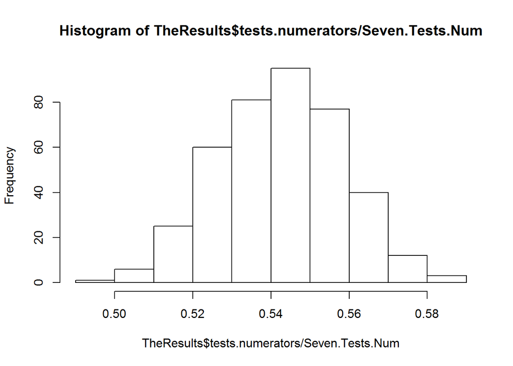

```r
hist(TheResults$tests.numerators/Seven.Tests.Num)
```